# MANOVA

Aula 13B — Análise Multivariada da Variância  
Análise de Dados Ambientais

Luiz Diego Vidal Santos

## Roteiro da Aula

- 1 Por que MANOVA?
- 2 Da ANOVA à MANOVA
- 3 Combinação linear das VDs
- 4 Pressupostos da MANOVA
- 5 Estatísticas de teste
- 6 Exemplo prático — Geotêxteis
- 7 MANOVA de Medidas Repetidas
- 8 Dados faltantes e relato dos resultados

**Objetivo:** Compreender a **MANOVA** como extensão multivariada da ANOVA, avaliando diferenças entre grupos quando há **múltiplas variáveis dependentes** correlacionadas.

# 1 — POR QUE MANOVA?

## O problema das várias ANOVAs

**Abordagem ingênua**

Fazer uma ANOVA separada para cada variável dependente:

- ANOVA₁: resistência à tração
- ANOVA₂: resistência à punção
- ANOVA₃: rigidez secante

Cada teste com α = 0,05.

**Inflação do Erro Tipo I**

Com 3 testes independentes:

$\alpha_{global} = 1 - (1 - 0{,}05)^3 = 0{,}143$

Probabilidade de **14,3%** de pelo menos um falso positivo.

**MANOVA: solução multivariada**

- Testa **todas as VDs simultaneamente**
- Mantém α = 0,05 para a família de testes
- Considera a **covariância** entre as VDs
- Pode detectar efeitos invisíveis em ANOVAs isoladas

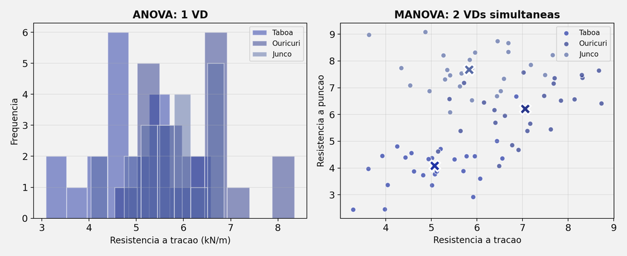

## Quando a MANOVA é a pergunta certa?

**Use MANOVA quando:**

- Há **uma ou mais VIs categóricas**
- Há **duas ou mais VDs contínuas**
- As VDs são conceitualmente relacionadas
- Você quer testar um efeito global do grupo sobre o **perfil multivariado**

**Exemplos ambientais**

| Fator | VDs simultâneas |
| --- | --- |
| Tipo de geotêxtil | Tração, punção, rigidez |
| Manejo do solo | Infiltração, densidade, C orgânico |
| Tratamento de água | pH, turbidez, condutividade |
| Restauração ecológica | Biomassa, cobertura, riqueza |

A MANOVA testa se os grupos diferem no **conjunto das variáveis dependentes**, não apenas em uma variável isolada.

# 2 — DA ANOVA À MANOVA

## A analogia central

**ANOVA (univariada)**

- Compara médias de **1 variável** entre grupos
- Usa a razão entre variância **entre** grupos e variância **dentro** dos grupos
- Estatística clássica: **F**
- Pergunta: as médias são iguais?

**MANOVA (multivariada)**

- Compara **vetores de médias** entre grupos
- Usa matrizes de **covariância** entre e dentro dos grupos
- Estatísticas: **Pillai, Wilks, Hotelling, Roy**
- Pergunta: os centroides são iguais?

**Da ANOVA para a MANOVA**

**ANOVA**

$$F = \frac{S^2_{\text{entre}}}{S^2_{\text{dentro}}}$$

Variâncias escalares.

→

**MANOVA**

$$\Lambda = \frac{|\mathbf{W}|}{|\mathbf{B} + \mathbf{W}|}$$

Determinantes de matrizes.

## Centroides multivariados

Na ANOVA, cada grupo tem uma **média**.

Na MANOVA, cada grupo tem um **centroide** — o vetor de médias de todas as VDs.

**Centroide do grupo “Taboa”**

$$\vec{\mu}_{Taboa} = \begin{pmatrix} \bar{x}_{tração} \\ \bar{x}_{punção} \\ \bar{x}_{rigidez} \end{pmatrix}$$

**Hipótese nula da MANOVA**

$$H_0: \vec{\mu}_1 = \vec{\mu}_2 = \vec{\mu}_3$$

Os centroides de todos os grupos são iguais: o tratamento não altera nenhuma combinação linear das VDs.

Se a MANOVA rejeita H₀, pelo menos um centroide difere. A etapa seguinte identifica **quais VDs** e **quais grupos** explicam a diferença.

# 3 — COMBINAÇÃO LINEAR DAS VDs

## O poder da combinação linear

**Exemplo com geotêxteis**

| Grupo | Resist. Tração | Resist. Punção | Rigidez |
| --- | --- | --- | --- |
| Taboa | Média₁ | Média₂ | Média₃ |
| Ouricuri | Média₄ | Média₅ | Média₆ |
| Junco | Média₇ | Média₈ | Média₉ |

Isoladamente, nenhuma variável pode distinguir os grupos. Mas a **combinação linear** das três pode revelar diferenças significativas.

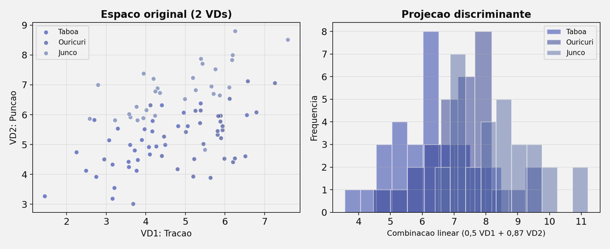

A MANOVA encontra a combinação linear das VDs que **maximiza** a separação entre os grupos — raciocínio próximo ao da Análise Discriminante.

## O que significa “efeito multivariado”?

**Efeito univariado**

Uma VD muda claramente entre os grupos.

Ex.: o geotêxtil A tem resistência à tração maior que B e C.

**Efeito multivariado**

Nenhuma VD isolada muda muito, mas o **perfil conjunto** das VDs muda.

Ex.: A é levemente melhor em tração, B em punção, C em rigidez — o padrão conjunto separa os grupos.

**Interpretação prática**

A MANOVA é útil quando as variáveis medem dimensões complementares de um mesmo sistema:

- propriedades mecânicas de materiais
- indicadores físico-químicos da água
- atributos físicos e biológicos do solo
- métricas de restauração ecológica

O ganho da MANOVA depende da **correlação entre as VDs**: se elas não se relacionam conceitual ou estatisticamente, a análise perde sentido.

# 4 — PRESSUPOSTOS DA MANOVA

## Pressupostos principais

**Herdados da ANOVA**

- Independência das observações
- VDs contínuas em escala intervalar/razão
- Tamanho amostral adequado em cada grupo
- Ausência de outliers extremos

**Específicos da MANOVA**

- **Normalidade multivariada**
- **Homogeneidade das matrizes de covariância**
- **Ausência de multicolinearidade excessiva** entre VDs
- Correlação entre VDs suficiente para justificar análise conjunta

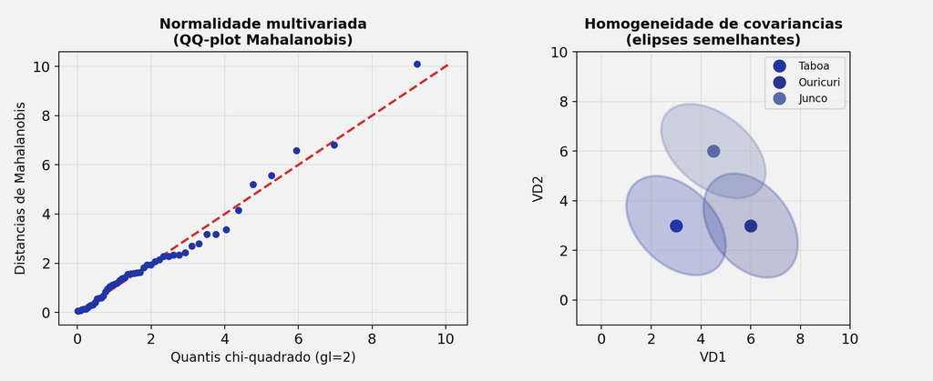

O teste M de Box avalia a equivalência das matrizes de covariância. Se **p < 0,001** (critério conservador), prefira o **Traço de Pillai**, que é mais robusto.

## Diagnóstico dos pressupostos

| Pressuposto | Diagnóstico | Critério prático |
| --- | --- | --- |
| Normalidade multivariada | Mardia, Henze-Zirkler, distâncias de Mahalanobis | Sem desvios extremos |
| Homogeneidade de covariância | Teste M de Box | p ≥ 0,001 desejável |
| Multicolinearidade entre VDs | Correlação entre VDs | Evitar $\lvert r \rvert > 0{,}90$ |
| Tamanho amostral | n por grupo | n > número de VDs em cada grupo |
| Outliers multivariados | Mahalanobis | Investigar casos extremos |

Quando os pressupostos são frágeis, relate a decisão: use **Pillai** como estatística principal e interprete Wilks apenas como informação complementar.

# 5 — ESTATÍSTICAS DE TESTE

## Quatro formas de testar a MANOVA

**Traço de Pillai (Pillai’s Trace)**

- Mais **robusto** a violações de pressupostos
- Recomendado como padrão
- Varia de 0 a s (nº de raízes)
- Bom com amostras desiguais

**Lambda de Wilks (Wilks’ Lambda)**

- Mais usado na literatura
- Varia de 0 a 1
- Valores pequenos favorecem rejeição de H₀
- Interpretação: variância multivariada **não explicada**

**Traço de Hotelling (Hotelling’s Trace)**

- Extensão do T² de Hotelling
- Adequado quando há apenas 2 grupos
- Mais poderoso quando pressupostos são atendidos

**Maior Raiz de Roy (Roy’s Largest Root)**

- Considera apenas a maior dimensão discriminante
- Útil quando a diferença está concentrada em uma dimensão
- Sensível a violações — usar com cautela

## Qual estatística escolher?

```
flowchart LR
    A["MANOVA\nsignificativa?"]:::root --> B{"Pressupostos\natendidos?"}:::node
    B --> |"Não"| C["Traço de\nPillai"]:::result
    B --> |"Sim"| D{"Quantos\ngrupos?"}:::node
    D --> |"2 grupos"| E["T² / Traço de\nHotelling"]:::result
    D --> |"≥ 3 grupos"| F{"Diferença em\n1 dimensão?"}:::node
    F --> |"Sim"| G["Raiz de\nRoy"]:::leaf
    F --> |"Não/incerto"| H["Wilks + Pillai"]:::result

    classDef root fill:#2135A6,color:#fff,font-weight:bold,stroke:#27368C
    classDef node fill:#C5CEE8,color:#0D0D0D,stroke:#586BA6
    classDef leaf fill:#586BA6,color:#fff,stroke:#27368C
    classDef result fill:#27368C,color:#fff,font-weight:bold,stroke:#2135A6
```

**Recomendação prática:** use o **Traço de Pillai** quando não tiver segurança plena sobre os pressupostos. Relate Wilks como estatística complementar quando a área costuma exigir esse indicador.

# 6 — EXEMPLO PRÁTICO

## Geotêxteis: Taboa × Ouricuri × Junco

**Delineamento**

| Elemento | Descrição |
| --- | --- |
| **Fator (VI)** | Tipo de fibra (Taboa, Ouricuri, Junco) |
| **VD₁** | Resistência à tração (kN/m) |
| **VD₂** | Resistência à punção (kN) |
| **VD₃** | Rigidez secante (kN/m) |
| **Teste** | MANOVA one-way |

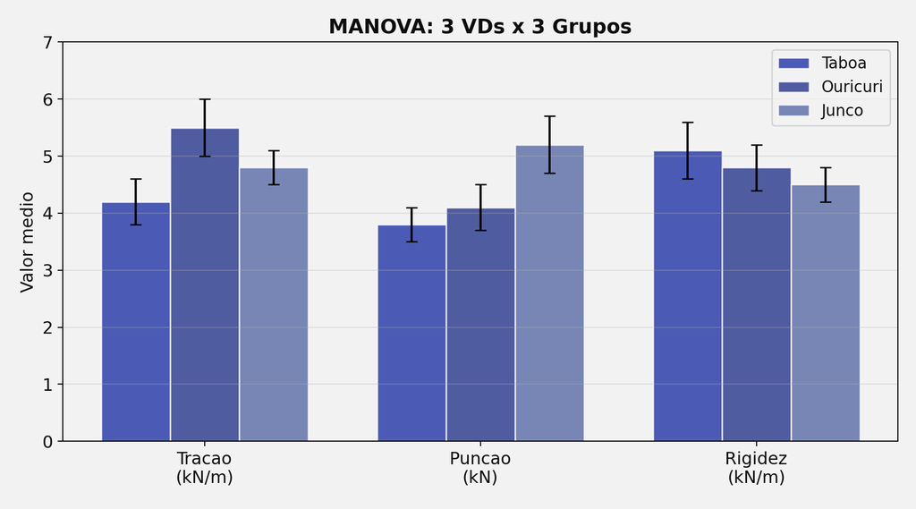

Isoladamente, cada VD pode não diferenciar os grupos (p > 0,05 nas ANOVAs individuais). A MANOVA pode revelar diferenças significativas na **combinação linear** das três propriedades mecânicas.

## Interpretação dos resultados

**Passo 1 — MANOVA global**

| Estatística | Valor | F | p |
| --- | --- | --- | --- |
| Traço de Pillai | 0,82 | 4,31 | 0,002 |
| Lambda de Wilks | 0,28 | 5,12 | < 0,001 |

Resultado: H₀ rejeitada → os centroides diferem.

**Passo 2 — ANOVAs de acompanhamento**

| VD | F | p | η² |
| --- | --- | --- | --- |
| Tração | 3,21 | 0,062 | 0,18 |
| Punção | 2,15 | 0,143 | 0,13 |
| Rigidez | 1,87 | 0,180 | 0,11 |

Nenhuma ANOVA individual significativa. A diferença está na **combinação** das VDs.

Este cenário ilustra o poder da MANOVA: mesmo quando ANOVAs individuais não detectam diferenças, a análise multivariada pode encontrá-las ao considerar a **estrutura de covariância** entre as VDs.

## Após a MANOVA significativa

**Sequência recomendada**

1 Verificar qual estatística global será relatada

2 Rodar ANOVAs de acompanhamento para cada VD

3 Controlar erro múltiplo (Bonferroni, Holm ou FDR)

4 Explorar dimensões discriminantes quando pertinente

A MANOVA responde à pergunta **global**: os grupos diferem no conjunto das VDs?

As análises seguintes respondem à pergunta **local**: onde, exatamente, está a diferença?

Não pule direto para várias ANOVAs sem relatar a MANOVA global. O ganho inferencial da abordagem está justamente no teste multivariado inicial.

# 7 — MANOVA-MR

## MANOVA de Medidas Repetidas

**Quando usar a MANOVA-MR?**

Quando temos:

- ≥ 2 variáveis dependentes
- Medidas repetidas ao longo do tempo ou condições
- Fatores entre-sujeitos opcionais

Ex.: resistência à tração **e** punção de geotêxteis medidas em 60, 120 e 180 dias.

**Vantagens sobre ANOVAs-MR separadas**

- Controla o erro Tipo I
- Analisa as VDs simultaneamente
- Não depende do pressuposto de **esfericidade** da mesma forma que a abordagem univariada
- Ganha poder quando as VDs são correlacionadas

A MANOVA-MR combina fatores entre e intra-sujeitos com múltiplas VDs. É uma extensão poderosa, mas exige amostras mais robustas e diagnóstico cuidadoso.

## MANOVA, MANCOVA e modelos mistos

| Situação | Técnica |
| --- | --- |
| 1 VD contínua, grupos independentes | ANOVA |
| 1 VD contínua + covariável contínua | ANCOVA |
| ≥ 2 VDs contínuas, grupos independentes | MANOVA |
| ≥ 2 VDs contínuas + covariável contínua | MANCOVA |
| ≥ 2 VDs + medidas repetidas/longitudinais | MANOVA-MR ou modelos mistos multivariados |

A MANCOVA é a ponte natural quando a pergunta é multivariada **e** há uma covariável contínua relevante, como precipitação, declividade, idade inicial ou biomassa basal.

# 8 — DADOS FALTANTES E RELATO

## Missing data na MANOVA

Dados faltantes são especialmente problemáticos na MANOVA porque cada sujeito precisa ter **todas as VDs** para ser incluído na análise.

**Tipos de missing**

| Tipo | Sigla | Mecanismo |
| --- | --- | --- |
| Completamente ao acaso | MCAR | Sem relação com variáveis |
| Ao acaso | MAR | Relacionado a variáveis observadas |
| Não ao acaso | MNAR | Relacionado ao próprio valor faltante |

**Métodos recomendados**

| Método | Quando usar |
| --- | --- |
| Exclusão listwise | Poucos missing (< 5%) |
| EM (Expected Maximization) | Missing moderado, padrão MAR |
| Imputação múltipla | Abordagem mais robusta |

Na pesquisa com geotêxteis, dados faltantes podem ocorrer quando corpos de prova **rompem antes do prazo**. Esse padrão tende a ser MNAR: o fato de faltar está relacionado à própria resistência.

## Como relatar os resultados

**Modelo de redação**

“Uma MANOVA one-way foi conduzida para avaliar o efeito do tipo de fibra (Taboa, Ouricuri e Junco) sobre três propriedades mecânicas: resistência à tração, resistência à punção e rigidez secante. O resultado global foi significativo pelo Traço de Pillai, V = 0,82, F(6, 52) = 4,31, p = 0,002, indicando diferença multivariada entre os grupos.”

**Checklist de reporte**

- Informar VIs e todas as VDs
- Relatar a estatística multivariada principal
- Informar F, gl, p e tamanho de efeito quando disponível
- Descrever pressupostos avaliados
- Apresentar análises de acompanhamento com ajuste para múltiplos testes

Evite dizer apenas “houve diferença significativa”. Em MANOVA, especifique que a diferença é **multivariada** e indique quais análises explicam o padrão encontrado.

## Resumo — Escolhendo a análise certa

```
flowchart LR
    A["Quantas VDs?"]:::root --> |"1 VD"| B{"Há\ncovariável?"}:::node
    A --> |"≥ 2 VDs"| C{"Há\ncovariável?"}:::node

    B --> |"Não"| D["ANOVA"]:::leaf
    B --> |"Sim"| E["ANCOVA"]:::result
    C --> |"Não"| F["MANOVA"]:::result
    C --> |"Sim"| G["MANCOVA"]:::result

    F --> H{"Medidas\nrepetidas?"}:::node
    H --> |"Sim"| I["MANOVA-MR"]:::result
    H --> |"Não"| J["MANOVA\none-way/fatorial"]:::leaf

    classDef root fill:#2135A6,color:#fff,font-weight:bold,stroke:#27368C
    classDef node fill:#C5CEE8,color:#0D0D0D,stroke:#586BA6
    classDef leaf fill:#586BA6,color:#fff,stroke:#27368C
    classDef result fill:#27368C,color:#fff,font-weight:bold,stroke:#2135A6
```

Obrigado!

Luiz Diego Vidal Santos

Universidade Estadual de Feira de Santana (UEFS)